# BI in Healthcare 23/24

### 3.1.4 Filter, Wrapping, Embedded-Verfahren

- Filtering: Man verwendet statistische Verfahren, um die Beziehung zwischen den Merkmalen und der Zielvariable zu analysieren. Dies kann beinhalten, dass man sich anschaut, wie Merkmale miteinander korrelieren, wie stark sie mit der Zielvariable zusammenhängen oder ob es signifikante Unterschiede zwischen den Klassen gibt. Filter-Verfahren bewerten die Merkmale auf Basis dieser statistischen Maße, um die relevanten Merkmale zu identifizieren. Statistische Tests (T-Test, Korrelation) helfen dabei, die erklärenden Variable zu finden. Alle Daten genutzt des Modells werden genutzt.
- Wrapping: Wrapper Verfahren verwenden tatsächliche Vorhersagemodelle, um die Qualität der Merkmale zu bewerten. Sie bewerten, wie gut ein Modell mit verschiedenen Merkmalsubsets auf einem Trainingsdatensatz abschneidet. Diese Methode ist modellabhängig, da sie die Leistung des Modells als Maß für die Merkmalsauswahl verwendet. Features werden schrittweise hinzugefügt oder entfernt, um die Leistung zu optimieren. Es wird jeweils nur ein Teil der Daten genutzt.
- Embedded-Verfahren: Filtering und Wrapping passieren nicht sequentiell, sondern Bestandteil der Modellkreierung. Embedded-Verfahren integrieren die Merkmalsauswahl in den Modelltrainingsprozess selbst. Das Modell analysiert automatisch die Relevanz der Merkmale während des Trainings und eliminiert unwichtige Features.

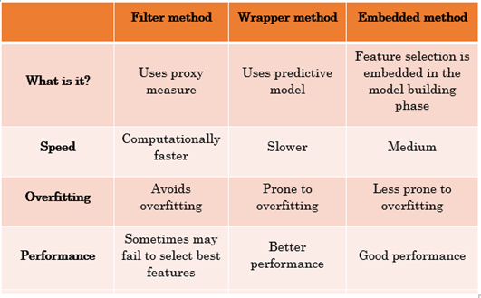

Quelle: https://www.datasciencesmachinelearning.com/2019/10/feature-selection-filter-method-wrapper.html

## 3.2 Übungsaufgaben

### 3.2.1 PCA mit mtcars

Die “Cumulative Proportion” PC1 liegt bei 60% und zusammen mit PC2 bereits bei über 84%. Das bedeutet, dass wir den mtcars Datensatz für weitere Modellentwicklung nutzen können.

```r
pc <- prcomp(mtcars, center = TRUE, scale = TRUE)
summary(pc)
```

```
## Importance of components:
##                           PC1    PC2     PC3     PC4     PC5     PC6    PC7
## Standard deviation     2.5707 1.6280 0.79196 0.51923 0.47271 0.46000 0.3678
## Proportion of Variance 0.6008 0.2409 0.05702 0.02451 0.02031 0.01924 0.0123
## Cumulative Proportion  0.6008 0.8417 0.89873 0.92324 0.94356 0.96279 0.9751
##                            PC8    PC9    PC10   PC11
## Standard deviation     0.35057 0.2776 0.22811 0.1485
## Proportion of Variance 0.01117 0.0070 0.00473 0.0020
## Cumulative Proportion  0.98626 0.9933 0.99800 1.0000
```

Interessant ist in diesem Fall auch der Biplot je Auto.

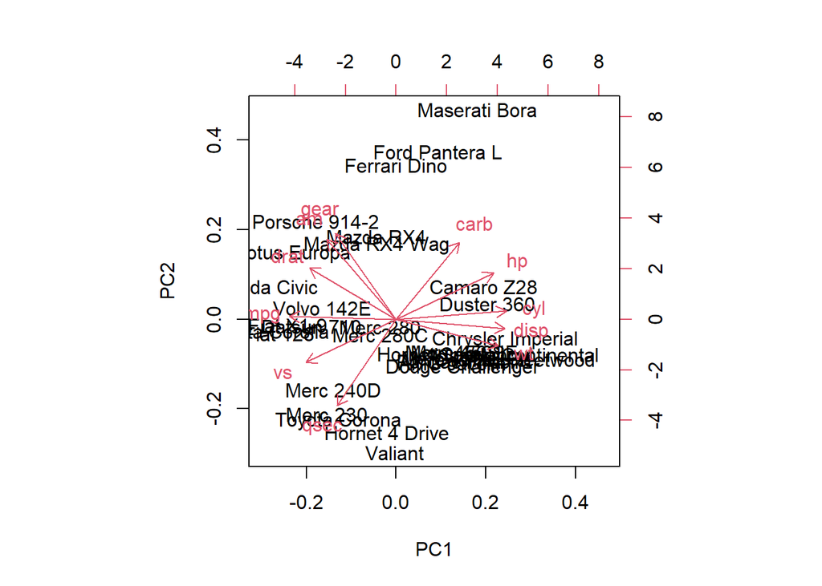

```r
biplot(pc)
```

Die “Sportwagen” sind im Biplot oben in der Mitte dargestellt, amerikanische Limusinen unten rechts und internationale “Kleinwagen” links.

### 3.2.2 Up/Down-Sampling

Beim Sampling werden unbalancierte Daten ausbalanciert. Wenn wir genug Daten haben, können wir Under-Sampling machen.

- Down-Sampling (Under): aus der Subgruppe mit vielen Daten wird eine Stichprobe zur Subgruppe mit wenigen Daten hinzugefügt, sodass schliesslich jeweils die Hälfte der Daten aus je einer Subgruppe stammt
- Up-Sampling (Over): Datensätze der Subgruppe mit wenigen Daten werden mehrfach verwendet (“ziehen mit zurücklegen”)

```r
library(MASS)
library(caret)
summary(biopsy$class)
```

```
##    benign malignant
##       458       241
```

```r
downSample <- downSample(biopsy, biopsy$class)
summary(downSample$class)
```

```
##    benign malignant
##       241       241
```

```r
upSample <- upSample(biopsy, biopsy$class)
summary(upSample$class)
```

```
##    benign malignant
##       458       458
```

## 3.3 Studierendenfragen

Hinweise, die sich aus unseren Fragen oder Multiple-Choise-Quiz ergeben haben und oben nicht erklärt wurden

- Das Prinzip der Kontraste müssen wir können. Details beispielsweise zu Helmert sind weniger wichtig.
- Skalieren: Abgleichen der Variablen, sodass die Varianz redzuiert wird (eine Variable von 0 bis 100 und eine andere von 0 bis 1). Regeressionmodell können die Niveauunterschiede ausgleichen, weil die Schätzer dann angepasst werden. Bei anderen Verfahren (La Sous?) gibt es aber einen Straftherm und dort beötgien wir Standardierung.
- Bias-Variance-Tradeoff? (p.28): Ich möchte im Mittel dort liegen, wo meine Zielgrösse ist; ich nehme aber in Kauf, dass ich von meinem Zielpunkt wegkomme und dakzeptiere dafür etwas mehr Varianz.
- Folie 24: trg$Species <- relevel(trg$Species, ref = “setosa”): Nein, bei ref = “setosa” handelt es sich hier nicht um Kontraste.
- Overfitting: ein Modell versucht, zu viel aus den Daten zu erklären, was sonst nur “Rauschen” wäre; Overfitting kann nicht durch durch Datenbereiningung vermieden werden, sondern auch durch zu wenige Daten entstehen. Gleichezitig passt sich ein zu komplexes Modell an Daten an
- Signifikanz spielt keine Rolle für PCA; PC1 und PC2 erklären die meiste Varianz, die mit einem Optimierungsverfahren zur Erklärung der maximalen Varianz berechnet wurden
- Over und untersampling können kombiniert werden (statt bei 90:10 zu 90:90 oder 10:10 selektieren wir 50:50 Fälle). Für Sampling berauchen wir keine Vereinteilungannahmen. Samples machen Subselect oder “zufällige” Vervielfachung.

# 4 Clustering

## 4.1 Hausaufgaben

### 4.1.1 Linkage Varianten

- Sinlge (min): ein Datenpunkt wird mit “direktem” Nachbarn verknüpft (mit kleinster Distanz), aber daraus können sich Ketten entstehen
- Complete (min/max): maximal entfernte Datenpunkte unterschiedlicher Cluter werden verglichen und die minimale Distanz dieser Distanzen genutzt (anfällig für Ausreisser)
- Average: Mittelwert der Entfernungen zwischen allen Datenpunktpaaren und davon der kleineste Abstand
- Centroid: Mittelwert jedes Clusters wird ermittelt und Distanz zwischen diesen Mittelpunkten betrachtet
- Ward: für jedes Cluster wird die Summe der quadrierten Distanzen der Datenpunkt vom Cluster-Centroid berechnet und alles aufsummiert. Danach werden diejenigen beiden Cluster vereinigt, deren Zusammenfügen die geringste Erhöhung der Gesamtsumme der quadrierten Distanzen zur Folge hat

### 4.1.2 Hierarchisches Clustering (iris)

Beginne mit kleinster Partitionierung (jede Datenpunkt = eigenes Cluster) und fusioniere Cluster bis ein zuvor festgelegtes Kriterium erfüllt ist.

- Berechnung der Distanz zwischen Cluster
- Fusion der Cluster mit kleinster Distanz (siehe Linkage-Frage oben)
- Berechnung des End-Kriteriums (ggfs. wieder von vorn)

Die voreingestelle Distanz-Berechnung ist “euclidean”. Die standard Linkage-Methode ist “complete”, kann aber überschrieben werden mit “ward.D”, “ward.D2”, “single”, “complete”, “average” (“avg”), “mcquitty”, “median” or “centroid” (“cen”).

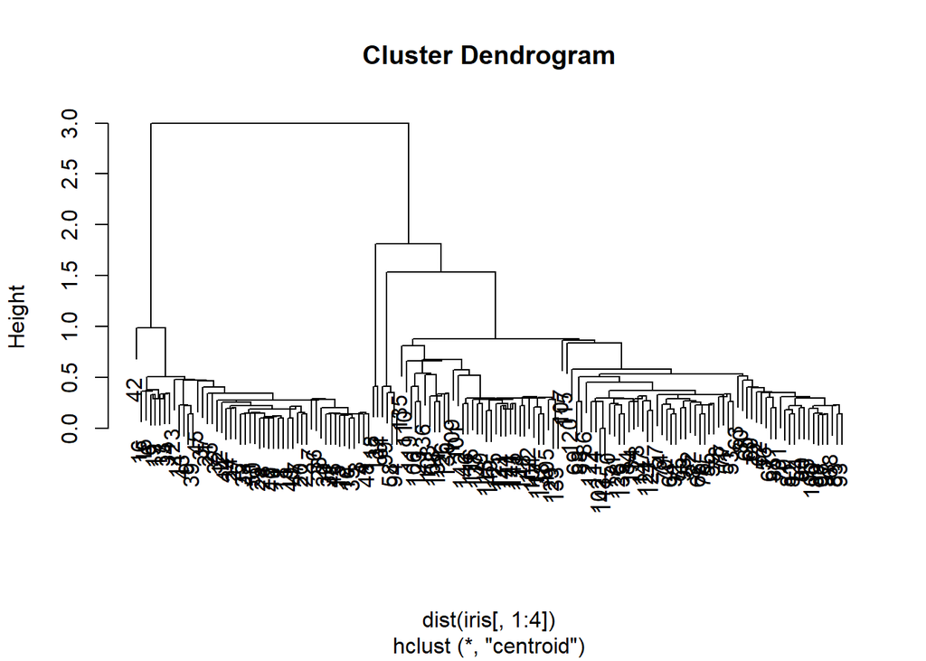

```r
iris_h_cluster <- hclust(dist(iris[,1:4]), method = "cen")
plot(iris_h_cluster)
```

Das Dendogramm zeigt mir, wo man einen “Schnitt” machen kann, um die Cluster zu trennen. Angenommen wir wollen drei Cluster produzieren, dann können wir dies wie folgt machen:

```r
groups_3 <- cutree(iris_h_cluster, 3)
table(groups_3, iris$Species)
```

```
##
## groups_3 setosa versicolor virginica
##        1     50          0         0
##        2      0         50        48
##        3      0          0         2
```

```r
library(cluster)
head(silhouette(cutree(iris_h_cluster,3), dist=dist(iris[,1:4])))
```

```
##      cluster neighbor sil_width
## [1,]       1        2 0.8738361
## [2,]       1        2 0.8429809
## [3,]       1        2 0.8536475
## [4,]       1        2 0.8341189
## [5,]       1        2 0.8704164
## [6,]       1        2 0.7841426
```

Silhouette: Für jede Zeile kann eine Silhouette berechnet werden. Distanzen eines Punktes 0 zu Cluster A oder B und davon die Differenz sowie mit dem Maximum der Distanz aus A der B normiert. Je grösser der Silhouette-Wert, desto besser ist die Zuordnung zum Cluster. Bei negativen Werten müsten die Daten eigentlich in ein anderes Cluster.

### 4.1.3 k-means Clutering (iris)

K-Means Clustering startet an einer fest definierten Anzahl an zufälligen Punkten und bezieht die Datenpunkte in der jeweiligen Umbegung mit ein. Dafür können einfach die Abstände ermittelt werden. Dann werden die Mittelwerte der jeweiligen Cluster neu berechnet, sodass sie sich mehr ins Zentrum des Clusters verschieben. Das geht solange, wie wir es definiert haben.

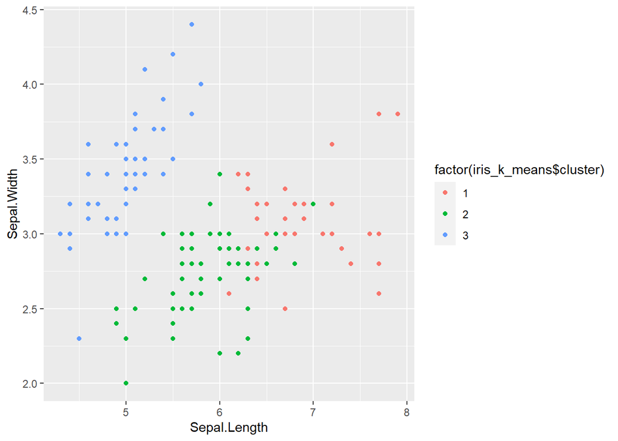

```r
iris_k_means <- kmeans(iris[,1:4], centers = 3)
ggplot(iris, aes(Sepal.Length, Sepal.Width)) +
  geom_point(aes(colour = factor(iris_k_means$cluster)))
```

```r
table(iris_k_means$cluster, iris$Species)
```

```
##
##     setosa versicolor virginica
##   1      0          2        36
##   2      0         48        14
##   3     50          0         0
```

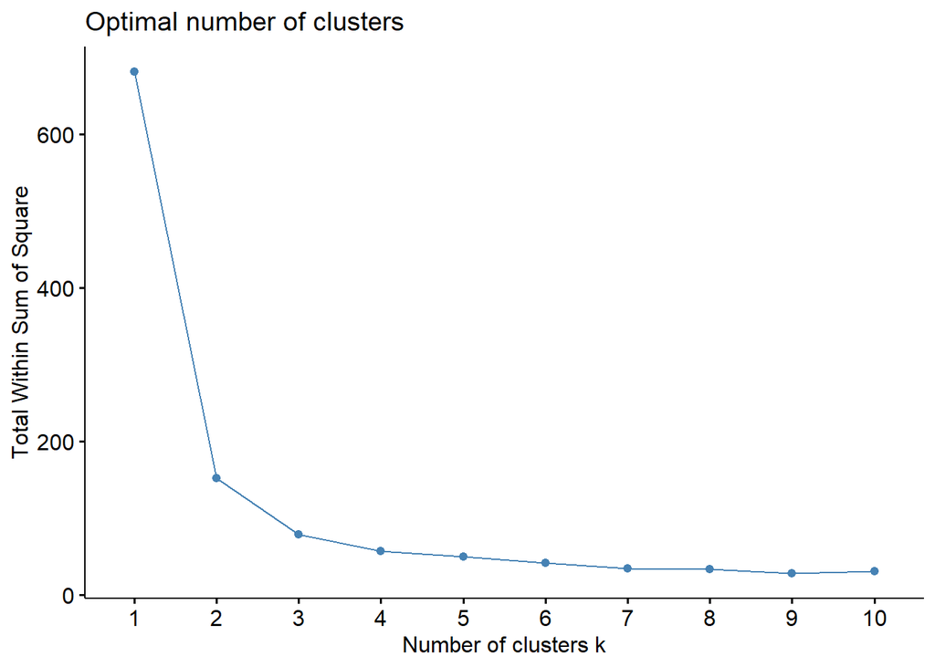

```r
library (factoextra)
fviz_nbclust(iris[,1:4], kmeans, method = "wss")
```

### 4.1.4 Vor- und Nachteile

- Für k-means werden keine Linkage Methoden benötigt.
- Dafür benötigen wir aber die Anzahl an “gewünschten” Cluster. Entweder mit dem Elbogendiagramm (mit Diameter oder erklärte Varianz) oder mit Siluhet.

### 4.1.5 Gradient Descent

Elegantere Herleitung des Lyod Algorithmus. Nach den zufälligen Startpunkten und initialer Zuteilung werden die neuen Mittelwerte berechnet. Danach wird die Zuordnung neu berechnet und ein Update-Mechanismus durchgeführt.

## 4.2 Übungsaufgaben

### 4.2.1 Hierarchisches Clustering (bike)

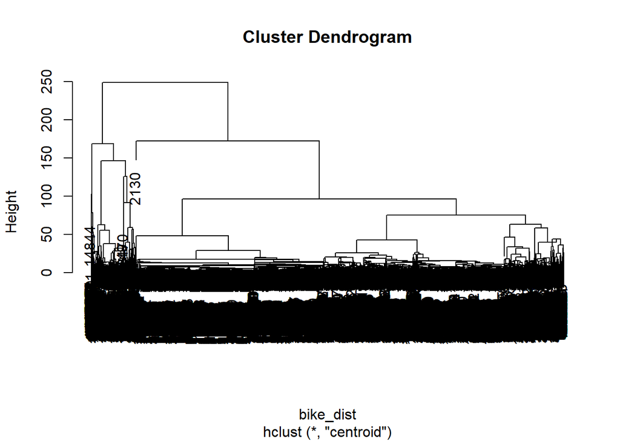

```r
library(cluster)
bike_dist <-dist(df_bike[,c("temp", "casual", "registered", "windspeed")])
bike_h_cluster <- hclust(bike_dist, method = "cen")
plot(bike_h_cluster)
```

Das Bike-Distanz-Objekt ist über 1 GB gross, sodass es hier gelöscht wird.

```r
rm(bike_dist)
```

### 4.2.2 k-means Clutering (bike)

Dieser Code funktioniert im Markdown-Skript, aber kann komischerweise nicht geknitet werden. Deshalb werden die Ergebnisse hier nicht angezeigt.

```r
library(ggplot2)
bike_c_columns <- df_bike[,c("temp", "casual", "registered", "windspeed")]
bike_km_cluster <- kmeans(bike_c_columns, centers = 6, iter.max = 20)
bike_km_cluster$size
ggplot(bike_c_columns, aes(registered, casual)) +
  geom_point(aes(colour = factor(bike_km_cluster$cluster)))
```

## 4.3 Studierendenfragen

- Spalten/Zeilen bei dist() (Distanzmatrix): alle Distanzen zum ersten Punkt in ersten Spalte, alle Distanzen zum zweiten Punkt in der zweiten Spalte etc.; aus Vereinfachungsgründen werden redundante Werte rausgelassen (im R-Output nur 7 Zeilen statt 150)

# 5 Machine Learning

## 5.1 Hausaufgaben

### 5.1.1 Overfittung

- Beim Overfitting ist das Modell zu gut an den Trainingsdatensatz angepasst.
- Auf Trainginsdaten toll, auf Testdaten nicht gut.
- Bei neuen Daten schneidet die Modellqualität dann jedoch schlecht ab, weil keine Verallgemeinerung mehr möglich ist.
- Beispiel: Selection Bias, d.h. die Daten werden an einem Ort erhoben, an denen keine repräsentative Auswahl der Population vorhanden ist (z.B. Umfrage im Sportverein bezüglich chronischer Krankheiten)

### 5.1.2 Generative und diskriminante Classifier

- Generativ: was ist die W’keit, die Klasse “nicht krank” und die entsprechenden Features im Kombination (Gesamtw’keit muss modelliert werden) –> bedingte W’keit steht hier im Vordergrund (ist das die “übliche” Vorhersage bei gegebenen, realen Inputs?) Beispiel: hat diese Person, die vor mit steht mit Alter 40, Raucher, etc.
- Diskriminativ: W’keit, dass ein Ereignis eintritt, wenn auch
- Naive Bayes-Klassifikatoren für binäre Merkmale werden unter logistische Regressionsklassifikatoren subsumiert.
- NB hängt für binäre Merkmale mathematisch mit der logistischen Regeression zusammen.

### 5.1.3 Aufgabe comedy/action

- Der Film mit den Worten fast, couple, shoot, fly wird vermutlcih nach NB ein Action-Film sein.
- Inklusive alpha = 1
- Wichtige Annahme: die Wörter seien unabhängig voneinander.

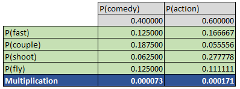

Herleitung

### 5.1.4 Naive Bayes auf bike

```r
library(tidyverse)
library(naivebayes)

nb_bike <- df_bike %>%
  dplyr::select(weather, temp, humidity, windspeed)
```

Der Datensatz wird in Trainingsdaten und Testdaten aufgeteilt und NB ausgeführt.

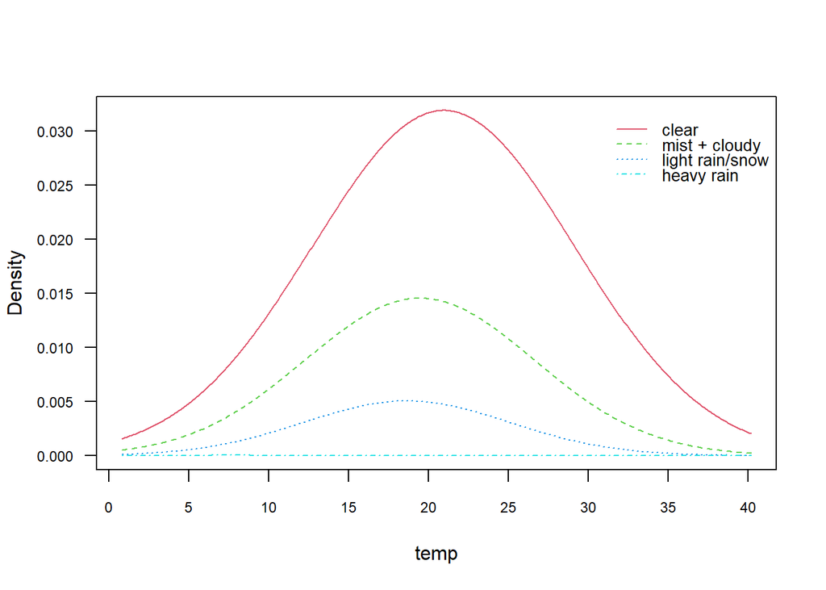

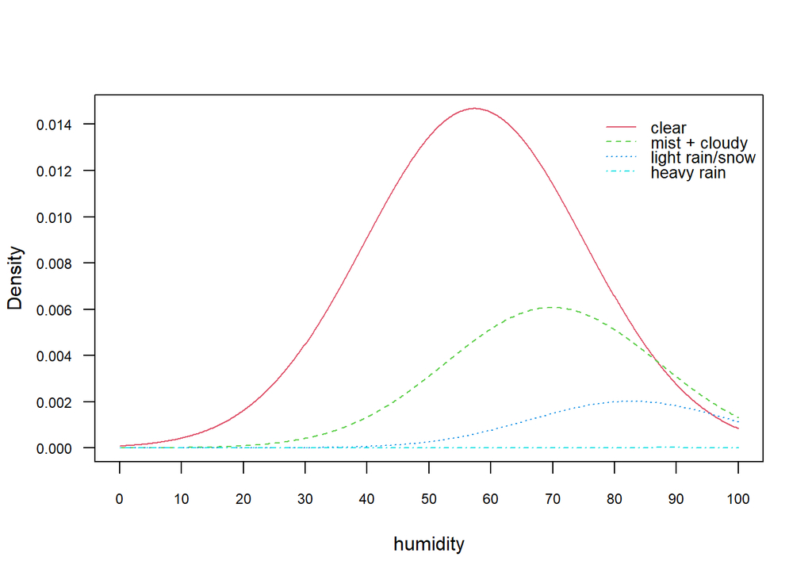

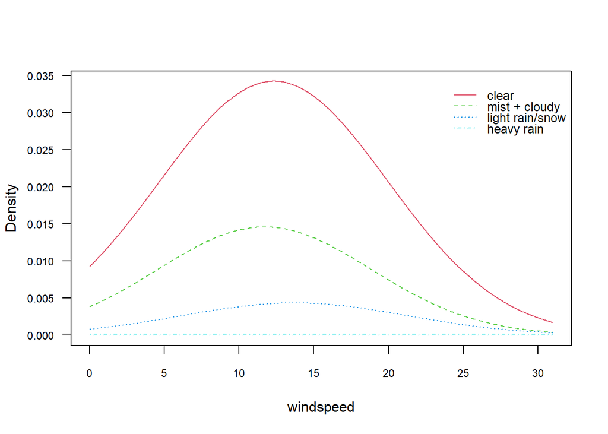

```r
set.seed(1234)
ind <- sample(2, nrow(nb_bike), replace = TRUE, prob = c(0.8, 0.2))
df_train <- nb_bike[ind == 1,]
df_test <- nb_bike[ind == 2,]
model <- naive_bayes(weather ~ ., data = df_train, laplace=3)
plot(model)
```

Wenn wir uns das Modell im Detail/Output anschauen, dann sehen wir hier auch die “Zähltabelle” für kategorielle variablen (hier habe ich nur stetige variablen, drum wurden nur mean/sd berechnet, die eine Gauss-Verteilung repräsentiert, eine Dichtefunktion wird somit berechnet). Vorhersage und Confusion Matrix wird erstellt.

```r
library(caret)
p <- predict(model, df_train[, 2:ncol(df_train)])
confusionMatrix(df_train[,"weather"],p)
```

```
## Confusion Matrix and Statistics
##
##                  Reference
## Prediction        clear mist + cloudy light rain/snow heavy rain
##   clear            8375           729               1          0
##   mist + cloudy    2703           889              52          0
##   light rain/snow   501           564              77          0
##   heavy rain          0             2               1          0
##
## Overall Statistics
##
##                Accuracy : 0.6723
##                  95% CI : (0.6644, 0.6801)
##     No Information Rate : 0.8334
##     P-Value [Acc > NIR] : 1
##
##                   Kappa : 0.2044
##
##  Mcnemar's Test P-Value : NA
##
## Statistics by Class:
##
##                      Class: clear Class: mist + cloudy Class: light rain/snow
## Sensitivity                0.7233              0.40705               0.587786
## Specificity                0.6847              0.76473               0.922619
## Pos Pred Value             0.9198              0.24396               0.067426
## Neg Pred Value             0.3310              0.87366               0.995765
## Prevalence                 0.8334              0.15719               0.009429
## Detection Rate             0.6028              0.06398               0.005542
## Detection Prevalence       0.6553              0.26227               0.082194
## Balanced Accuracy          0.7040              0.58589               0.755202
##                      Class: heavy rain
## Sensitivity                         NA
## Specificity                  0.9997841
## Pos Pred Value                      NA
## Neg Pred Value                      NA
## Prevalence                   0.0000000
## Detection Rate               0.0000000
## Detection Prevalence         0.0002159
## Balanced Accuracy                   NA
```

Die Vorhersage auf Basis der Trainingsdaten ist “solala” und auf Basis der Test-Daten auch nicht viel besser. Dies kann man an der “Accuracy” von 0.6723 ablesen.

```r
p_test <- predict(model, df_test[, 2:ncol(df_test)])
confusionMatrix(df_test[,"weather"],p_test)
```

```
## Confusion Matrix and Statistics
##
##                  Reference
## Prediction        clear mist + cloudy light rain/snow heavy rain
##   clear            2113           195               0          0
##   mist + cloudy     665           222              13          0
##   light rain/snow   129           127              21          0
##   heavy rain          0             0               0          0
##
## Overall Statistics
##
##                Accuracy : 0.676
##                  95% CI : (0.6602, 0.6916)
##     No Information Rate : 0.8341
##     P-Value [Acc > NIR] : 1
##
##                   Kappa : 0.203
##
##  Mcnemar's Test P-Value : NA
##
## Statistics by Class:
##
##                      Class: clear Class: mist + cloudy Class: light rain/snow
## Sensitivity                0.7269               0.4081               0.617647
## Specificity                0.6626               0.7695               0.925819
## Pos Pred Value             0.9155               0.2467               0.075812
## Neg Pred Value             0.3254               0.8754               0.995948
## Prevalence                 0.8341               0.1561               0.009756
## Detection Rate             0.6063               0.0637               0.006026
## Detection Prevalence       0.6623               0.2582               0.079484
## Balanced Accuracy          0.6947               0.5888               0.771733
##                      Class: heavy rain
## Sensitivity                         NA
## Specificity                          1
## Pos Pred Value                      NA
## Neg Pred Value                      NA
## Prevalence                           0
## Detection Rate                       0
## Detection Prevalence                 0
## Balanced Accuracy                   NA
```

Aber immerhin verhalten sich die Testdaten “ähnlich” wie die Trainingsdaten.

### 5.1.5 rpart auf bike

Die Library wird geladen. Da wir voher schon den Trainings- und Testdatensatz erstellt haben, können wir direkt das Modell laufen lassen.

```r
library(rpart)
fit <- rpart(weather ~ ., method="class", data=df_train, cp=0.001)
printcp(fit) # display the results
```

```
##
## Classification tree:
## rpart(formula = weather ~ ., data = df_train, method = "class",
##     cp = 0.001)
##
## Variables actually used in tree construction:
## [1] humidity  temp      windspeed
##
## Root node error: 4789/13894 = 0.34468
##
## n= 13894
##
##           CP nsplit rel error  xerror     xstd
## 1  0.0250574      0   1.00000 1.00000 0.011698
## 2  0.0133640      2   0.94989 0.95239 0.011558
## 3  0.0087701      3   0.93652 0.94362 0.011531
## 4  0.0085613      4   0.92775 0.94320 0.011529
## 5  0.0037586      5   0.91919 0.94028 0.011520
## 6  0.0020881      6   0.91543 0.92900 0.011483
## 7  0.0019837      9   0.90812 0.92525 0.011471
## 8  0.0017749     13   0.90019 0.92190 0.011460
## 9  0.0013573     16   0.89455 0.91856 0.011449
## 10 0.0010441     20   0.88849 0.91940 0.011452
## 11 0.0010000     23   0.88536 0.91815 0.011448
```

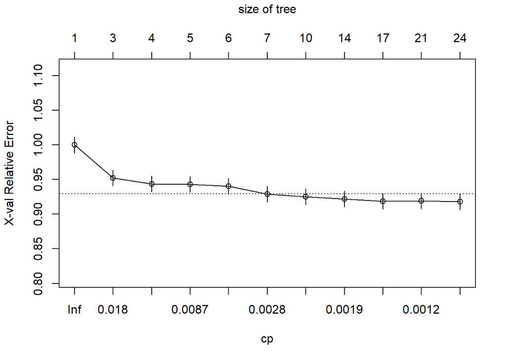

```r
plotcp(fit) # visualize cross-validation results
```

```r
# summary(fit)
```

In der Summary wird der CP (Complexity Parameter) angegeben. Es wird verzweigt, sodass neue Klasse/Knoten entstehen, die mehr von der jeweiligen Klasse aufweisen (mehr “Reinheit”). Der Entscheidungsbaum ist wie ein “Sieb”. Hier gibt es noch die Begriffe Entrophie und Gini-Koeffizient, auf dessen Basis die Reinheit/Unreinheits-Knotenaufteilung erfolgt. Dies Aufteilung sieht man auf Basus der primary Splits und der weiteren Angaben in der Summary, die hier nicht dargestellt werden.

Die Baumstruktur ergibt sich wie folgt.

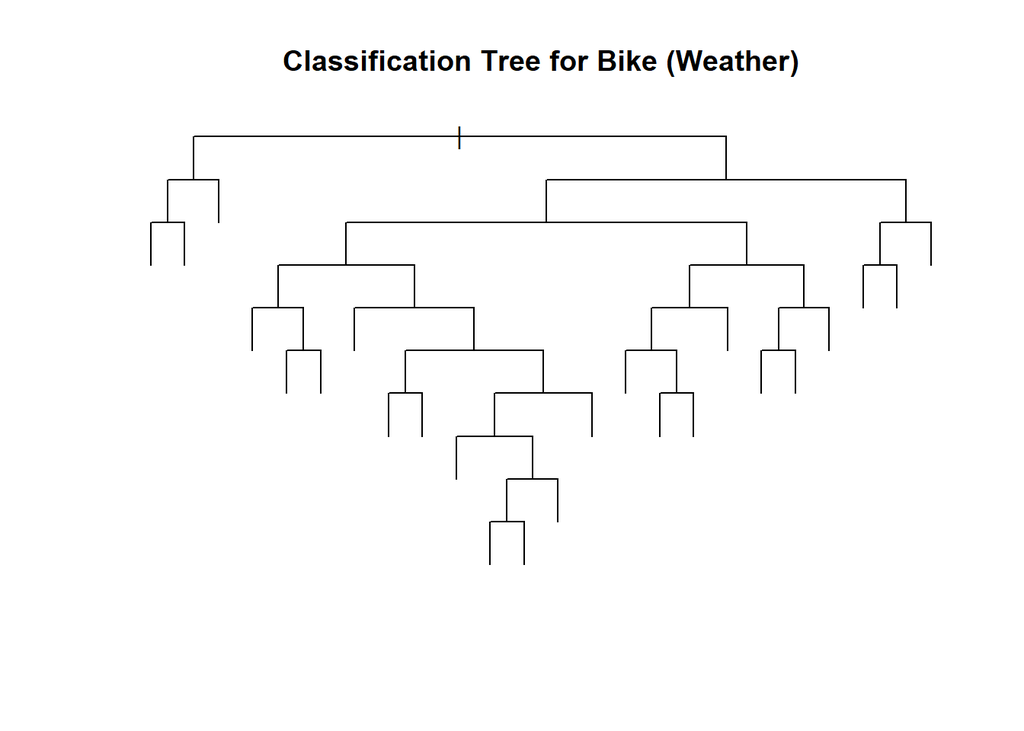

```r
# plot tree
plot(fit, uniform=TRUE, main="Classification Tree for Bike (Weather)")
```

Und schliesslich prüfen wir wieder die Vorhersage des Modells.

```r
p <- predict(fit, df_test[, -1], type = c("prob"))
fitted.results <- ifelse(p[,2] > 0.5,1,0)
table(fitted.results, df_test$weather)
```

```
##
## fitted.results clear mist + cloudy light rain/snow heavy rain
##              0  2282           880             270          0
##              1    26            20               7          0
```

## 5.2 Übungsaufgaben

### 5.2.1 Under-/Down-Sampling

```r
library(MASS)
library(caret)
summary(biopsy$class)
```

```
##    benign malignant
##       458       241
```

```r
downSample <- downSample(biopsy, biopsy$class)
summary(downSample$class)
```

```
##    benign malignant
##       241       241
```

```r
upSample <- upSample(biopsy, biopsy$class)
summary(upSample$class)
```

```
##    benign malignant
##       458       458
```

### 5.2.2 rpart auf kyphosis Datensatz

## 5.3 Studierendenfragen

- angewendet auf den Bike-Datensatz: was genau sagen uns die beiden Modelle?

# 6 Text Mining

## 6.1 Allgemeines

- Semi-Automatisierter Prozess auf Basis von Texten
- Fokus: Kerninformationen finden
- Vorgehen
  - Problem und Ziele definieren
  - Daten/Text sammeln
  - Daten aufbereiten
  - Tokenisieren
  - Grundformen, Stopword etc.
  - Analysieren und interpretieren
- Abgrenzung zu NLP
  - NLP inkl. Semantik (Verstehen des Textes, Bedeutung der Wörter)
  - NLP inkl. Audio und für Übersetzungen und weiterführende Anwendungen
- Sentiments berücksichtigen die Bedeutungsrichtung von Wörtern (positiv, negativ etc.)

## 6.2 Hausaufgaben

### 6.2.1 Word Embeddings und PCA

Word Embeddings respräsentieren Wörter mit “gleicher” Bedeutung in einem n-Dimensionalen Raum, sodass Men/Women und Kind/Queen oder walk/walked und swim/swam “gleichartig” repräsentiert werden

### 6.2.2 skip_ngrams und nnest_tokens

### 6.2.3 Wordcloud

[Word Cloud of the SwissDRG “Definitionshandbuch”.](https://teletrabbie.github.io/word_cloud_drg.html)

### 6.2.4 Sentiment-Anayse in der Praxis

Produktanalysen, gesellschaftliche Fragestellungen etc.

## 6.3 Übungsaufgaben